# 3. Modeling

- This notebook includes training and evaluation of six tree-based classification models (Random Forest, XGBoost, and LightGBM, each in two training window configurations), together with a soft voting ensemble that averages predicted probabilities across all six models.
- All models use a walk-forward validation scheme: the training window rolls forward in 21-day steps, with `RandomizedSearchCV` and nested `TimeSeriesSplit` inner cross-validation re-run at each step.
- A random walk benchmark (yesterday's direction as the prediction) is included as a naive baseline.
- Feature importance is computed using SHAP values.
- SHAP values are normalized per model so that each model's attributions sum to 1, making relative feature importance comparable across different models.
- Predictions are saved to `predictions.csv` and are used in the backtest.

### Machine learning models

- All three model families — Random Forest, XGBoost, and LightGBM — belong to the class of tree-based ensemble methods. They are well-suited for this task because they handle non-linear relationships, feature interactions, and noisy data without requiring normalization or distributional assumptions about the input features.
- Random Forest builds a large number of decision trees independently using bootstrap sampling and random feature subsets at each split. Final predictions are averaged across all trees, which reduces variance and prevents overfitting.
- XGBoost uses gradient boosting: trees are built sequentially, where each new tree corrects the residual errors of the previous ensemble.
- LightGBM follows the same gradient boosting principle as XGBoost but uses leaf-wise tree growth instead of depth-wise. This makes it significantly faster on high-dimensional data while achieving comparable predictive accuracy.

### Walk-forward validation scheme

- Standard cross-validation randomly splits data into folds, which causes data leakage in time series — future observations end up in the training set.
- Walk-forward validation avoids this by strictly respecting the chronological order of data.
- The procedure works as follows: A fixed-size training window is placed at the start of the dataset. The model is trained on this window and used to predict the next 21 trading days (one month). The window then shifts forward by 21 days and the process repeats — each step trains a fresh model on the most recent data and predicts the next unseen period.
- Hyperparameter tuning is performed inside each training window using a nested `TimeSeriesSplit` cross-validation with `RandomizedSearchCV`. This means the best hyperparameters are re-selected at every step.
- Two window sizes are tested for each model family: 252 trading days (~1 year) and 504 trading days (~2 years).
- The scheme is illustrated in the figure below.

[figure not shown]

## Setup

```python
# Importing libraries
import pandas as pd
import numpy as np
import matplotlib.pyplot as plt

from sklearn.ensemble import RandomForestClassifier
from xgboost import XGBClassifier
from lightgbm import LGBMClassifier

from sklearn.model_selection import TimeSeriesSplit, RandomizedSearchCV
from sklearn.metrics import accuracy_score, confusion_matrix, roc_auc_score
from scipy.stats import randint, uniform
import shap

import warnings
warnings.filterwarnings("ignore")
```

```python
# Reading the dataset with features
df = pd.read_csv("../Data/features.csv")
df["date"] = pd.to_datetime(df["date"], format="%Y-%m-%d")
df.set_index("date", inplace=True)
```

```python
# Setting aside SPY returns and defining features (X) and the target (y)
spy_return = df["spy_return"]
df.drop("spy_return", axis=1, inplace=True)

X = df.drop(columns=["spy_direction"])
y = df["spy_direction"]
```

```python
# Predictions dataframe
predictions = pd.DataFrame({
    "spy_return":   spy_return.iloc[504:],
    "y_true":       y.iloc[504:],
})
```

```python
# Evaluate dataframe and function
eval = pd.DataFrame(
    columns=["Accuracy", "AUC", "Sensitivity", "Specificity"]
)

def evaluate(model_name, y_true, y_pred, y_prob, eval):
    print(confusion_matrix(y_true, y_pred))
    tn, fp, fn, tp = confusion_matrix(y_true, y_pred).ravel()
    row = pd.DataFrame([{
        "Accuracy":    round(accuracy_score(y_true, y_pred), 3),
        "AUC":         round(roc_auc_score(y_true, y_prob), 3),
        "Sensitivity": round(tp / (tp + fn), 3),
        "Specificity": round(tn / (tn + fp), 3),
    }], index=[model_name])
    return pd.concat([eval, row])
```

## Random walk benchmark

```python
# Random walk
predictions["rw"] = y.shift(1).iloc[504:]

# Evaluation
eval = evaluate(
    "RW",
    predictions["y_true"],
    predictions["rw"],
    predictions["rw"],
    eval
)
eval
```

```
[[384 476]
 [476 588]]
```

|  | Accuracy | AUC | Sensitivity | Specificity |
| --- | --- | --- | --- | --- |
| RW | 0.505 | 0.5 | 0.553 | 0.447 |

## Random Forest models

### Walk-Forward Evaluation function

```python
def walk_forward_rf(X, y, train_window, cv_train_window, val_window, step, param_distributions, n_iter):

    results = []
    shap_rows = []
    train_start = 0
    train_end = train_window

    n_splits = (train_window - cv_train_window) // val_window
    inner_cv = TimeSeriesSplit(n_splits=n_splits, max_train_size=cv_train_window, test_size=val_window)

    while train_end < len(X):
        X_train = X.iloc[train_start:train_end]
        y_train = y.iloc[train_start:train_end]

        search = RandomizedSearchCV(
            RandomForestClassifier(random_state=1, class_weight="balanced"),
            param_distributions,
            n_iter=n_iter,
            cv=inner_cv,
            scoring="balanced_accuracy",
            random_state=1,
            n_jobs=-1,
        )
        search.fit(X_train, y_train)
        print(f"{X_train.index[-1].date()} | best params: {search.best_params_}")

        pred_end = min(train_end + step, len(X))
        X_pred = X.iloc[train_end:pred_end]
        y_true = y.iloc[train_end:pred_end]
        preds = search.best_estimator_.predict(X_pred)
        probs = search.best_estimator_.predict_proba(X_pred)[:, 1]

        for date, tv, pv, pb in zip(X_pred.index, y_true, preds, probs):
            results.append({"date": date, "y_true": tv, "y_pred": pv, "prob_up": pb})

        explainer = shap.TreeExplainer(search.best_estimator_)
        shap_vals = explainer.shap_values(X_pred)
        sv = shap_vals[:, :, 1] if hasattr(shap_vals, 'ndim') and shap_vals.ndim == 3 else shap_vals[1]
        shap_rows.append(pd.DataFrame(sv, index=X_pred.index, columns=X_pred.columns))

        train_start += step
        train_end += step

    results_df = pd.DataFrame(results).set_index("date")
    shap_df = pd.concat(shap_rows)
    return results_df, shap_df
```

### Parameter grid setup

```python
param_distributions_rf = {
    "n_estimators":         randint(100, 500),
    "max_depth":            [3, 4, 5, 6, None],
    "min_samples_leaf":     randint(5, 30),
    "min_samples_split":    randint(10, 40),
    "max_features":         ["sqrt", "log2", 0.5]
}
```

### RF 252

```python
%%capture

# Walk-forward evaluation
rf_252, shap_rf252 = walk_forward_rf(
    X, y,
    train_window=252,
    cv_train_window=126,
    val_window=21,
    step=21,
    n_iter=30,
    param_distributions=param_distributions_rf
)
```

```python
# Predictions
predictions["rf252"] = rf_252["y_pred"]
predictions["rf252_prob"] = rf_252["prob_up"]
```

```python
# Evaluation
eval = evaluate(
    "RF-252",
    predictions["y_true"],
    predictions["rf252"],
    predictions["rf252_prob"],
    eval
)
eval
```

```
[[387 473]
 [468 596]]
```

|  | Accuracy | AUC | Sensitivity | Specificity |
| --- | --- | --- | --- | --- |
| RW | 0.505 | 0.500 | 0.553 | 0.447 |
| RF-252 | 0.511 | 0.504 | 0.560 | 0.450 |

### RF 504

```python
%%capture

# Walk-forward evaluation
rf_504, shap_rf504 = walk_forward_rf(
    X, y,
    train_window=504,
    cv_train_window=252,
    val_window=21,
    step=21,
    n_iter=30,
    param_distributions=param_distributions_rf
)
```

```python
# Predictions
predictions["rf504"] = rf_504["y_pred"]
predictions["rf504_prob"] = rf_504["prob_up"]
```

```python
# Evaluation
eval = evaluate(
    "RF-504",
    predictions["y_true"],
    predictions["rf504"],
    predictions["rf504_prob"],
    eval
)
eval
```

```
[[362 498]
 [420 644]]
```

|  | Accuracy | AUC | Sensitivity | Specificity |
| --- | --- | --- | --- | --- |
| RW | 0.505 | 0.500 | 0.553 | 0.447 |
| RF-252 | 0.511 | 0.504 | 0.560 | 0.450 |
| RF-504 | 0.523 | 0.514 | 0.605 | 0.421 |

## XGBoost Models

### Walk-Forward Evaluation function

```python
def walk_forward_xgb(X, y, train_window, cv_train_window, val_window, step, param_distributions, n_iter):

    results = []
    shap_rows = []
    train_start = 0
    train_end = train_window

    n_splits = (train_window - cv_train_window) // val_window
    inner_cv = TimeSeriesSplit(n_splits=n_splits, max_train_size=cv_train_window, test_size=val_window)

    while train_end < len(X):
        X_train = X.iloc[train_start:train_end]
        y_train = y.iloc[train_start:train_end]

        neg = (y_train == 0).sum()
        pos = (y_train == 1).sum()
        spw = neg / pos

        search = RandomizedSearchCV(
            XGBClassifier(random_state=1, scale_pos_weight=spw, eval_metric="logloss"),
            param_distributions,
            n_iter=n_iter,
            cv=inner_cv,
            scoring="balanced_accuracy",
            random_state=1,
            n_jobs=-1,
        )
        search.fit(X_train, y_train)
        print(f"{X_train.index[-1].date()} | best params: {search.best_params_}")

        pred_end = min(train_end + step, len(X))
        X_pred = X.iloc[train_end:pred_end]
        y_true = y.iloc[train_end:pred_end]
        preds = search.best_estimator_.predict(X_pred)
        probs = search.best_estimator_.predict_proba(X_pred)[:, 1]

        for date, tv, pv, pb in zip(X_pred.index, y_true, preds, probs):
            results.append({"date": date, "y_true": tv, "y_pred": pv, "prob_up": pb})

        explainer = shap.TreeExplainer(search.best_estimator_)
        shap_vals = explainer.shap_values(X_pred)
        shap_rows.append(pd.DataFrame(shap_vals, index=X_pred.index, columns=X_pred.columns))

        train_start += step
        train_end += step

    results_df = pd.DataFrame(results).set_index("date")
    shap_df = pd.concat(shap_rows)
    return results_df, shap_df
```

### Parameter grid setup

```python
# Parameter distributions
param_distributions_xgb = {
    "n_estimators":     randint(100, 600),
    "max_depth":        [3, 4, 5, 6],
    "learning_rate":    uniform(0.01, 0.19),
    "subsample":        uniform(0.6, 0.4),
    "colsample_bytree": uniform(0.5, 0.5),
    "min_child_weight": randint(3, 15),
    "gamma":            uniform(0, 1),
    "reg_lambda":       uniform(1.0, 4.0)
}
```

### XGB 252

```python
%%capture

# Walk-forward evaluation
xgb_252, shap_xgb252 = walk_forward_xgb(
    X, y,
    train_window=252,
    cv_train_window=126,
    val_window=21,
    step=21,
    n_iter=30,
    param_distributions=param_distributions_xgb
)
```

```python
# Predictions
predictions["xgb252"] = xgb_252["y_pred"]
predictions["xgb252_prob"] = xgb_252["prob_up"]
```

```python
# Evaluation
eval = evaluate(
    "XGB-252",
    predictions["y_true"],
    predictions["xgb252"],
    predictions["xgb252_prob"],
    eval
)
eval
```

```
[[391 469]
 [480 584]]
```

|  | Accuracy | AUC | Sensitivity | Specificity |
| --- | --- | --- | --- | --- |
| RW | 0.505 | 0.500 | 0.553 | 0.447 |
| RF-252 | 0.511 | 0.504 | 0.560 | 0.450 |
| RF-504 | 0.523 | 0.514 | 0.605 | 0.421 |
| XGB-252 | 0.507 | 0.500 | 0.549 | 0.455 |

### XGB 504

```python
%%capture

# Walk-forward evaluation
xgb_504, shap_xgb504 = walk_forward_xgb(
    X, y,
    train_window=504,
    cv_train_window=252,
    val_window=21,
    step=21,
    n_iter=30,
    param_distributions=param_distributions_xgb
)
```

```python
# Predictions
predictions["xgb504"] = xgb_504["y_pred"]
predictions["xgb504_prob"] = xgb_504["prob_up"]
```

```python
# Evaluation
eval = evaluate(
    "XGB-504",
    predictions["y_true"],
    predictions["xgb504"],
    predictions["xgb504_prob"],
    eval
)
eval
```

```
[[399 461]
 [451 613]]
```

|  | Accuracy | AUC | Sensitivity | Specificity |
| --- | --- | --- | --- | --- |
| RW | 0.505 | 0.500 | 0.553 | 0.447 |
| RF-252 | 0.511 | 0.504 | 0.560 | 0.450 |
| RF-504 | 0.523 | 0.514 | 0.605 | 0.421 |
| XGB-252 | 0.507 | 0.500 | 0.549 | 0.455 |
| XGB-504 | 0.526 | 0.523 | 0.576 | 0.464 |

## LightGBM Models

### Walk-forward evaluation function

```python
def walk_forward_lgb(X, y, train_window, cv_train_window, val_window, step, param_distributions, n_iter):

    results = []
    shap_rows = []
    train_start = 0
    train_end = train_window

    n_splits = (train_window - cv_train_window) // val_window
    inner_cv = TimeSeriesSplit(n_splits=n_splits, max_train_size=cv_train_window, test_size=val_window)

    while train_end < len(X):
        X_train = X.iloc[train_start:train_end]
        y_train = y.iloc[train_start:train_end]

        neg = (y_train == 0).sum()
        pos = (y_train == 1).sum()
        spw = neg / pos

        search = RandomizedSearchCV(
            LGBMClassifier(
                random_state=1,
                scale_pos_weight=spw,
                subsample_freq=1,
                verbose=-1,
                n_jobs=1,
            ),
            param_distributions,
            n_iter=n_iter,
            cv=inner_cv,
            scoring="balanced_accuracy",
            random_state=1,
            n_jobs=-1,
        )
        search.fit(X_train, y_train)
        print(f"{X_train.index[-1].date()} | best params: {search.best_params_}")

        pred_end = min(train_end + step, len(X))
        X_pred = X.iloc[train_end:pred_end]
        y_true = y.iloc[train_end:pred_end]
        preds = search.best_estimator_.predict(X_pred)
        probs = search.best_estimator_.predict_proba(X_pred)[:, 1]

        for date, tv, pv, pb in zip(X_pred.index, y_true, preds, probs):
            results.append({"date": date, "y_true": tv, "y_pred": pv, "prob_up": pb})

        explainer = shap.TreeExplainer(search.best_estimator_)
        shap_vals = explainer.shap_values(X_pred)
        shap_rows.append(pd.DataFrame(shap_vals, index=X_pred.index, columns=X_pred.columns))

        train_start += step
        train_end += step

    results_df = pd.DataFrame(results).set_index("date")
    shap_df = pd.concat(shap_rows)
    return results_df, shap_df
```

```python
param_distributions_lgb = {
    "n_estimators":         randint(100, 600),
    "max_depth":            [3, 4, 5, 6],
    "learning_rate":        uniform(0.01, 0.19),
    "subsample":            uniform(0.6, 0.4),
    "colsample_bytree":     uniform(0.5, 0.5),
    "min_child_samples":    randint(3, 15),
    "reg_alpha":            uniform(0, 1),
    "reg_lambda":           uniform(1.0, 4.0)
}
```

### LightGBM 252

```python
%%capture

# Walk-forward evaluation
lgb_252, shap_lgb252 = walk_forward_lgb(
    X, y,
    train_window=252,
    cv_train_window=126,
    val_window=21,
    step=21,
    n_iter=30,
    param_distributions=param_distributions_lgb
)
```

```python
# Predictions
predictions["lgb252"] = lgb_252["y_pred"]
predictions["lgb252_prob"] = lgb_252["prob_up"]
```

```python
# Evaluation
eval = evaluate(
    "LGB-252",
    predictions["y_true"],
    predictions["lgb252"],
    predictions["lgb252_prob"],
    eval
)
eval
```

```
[[364 496]
 [457 607]]
```

|  | Accuracy | AUC | Sensitivity | Specificity |
| --- | --- | --- | --- | --- |
| RW | 0.505 | 0.500 | 0.553 | 0.447 |
| RF-252 | 0.511 | 0.504 | 0.560 | 0.450 |
| RF-504 | 0.523 | 0.514 | 0.605 | 0.421 |
| XGB-252 | 0.507 | 0.500 | 0.549 | 0.455 |
| XGB-504 | 0.526 | 0.523 | 0.576 | 0.464 |
| LGB-252 | 0.505 | 0.503 | 0.570 | 0.423 |

### LightGBM 504

```python
%%capture

# Walk-forward evaluation
lgb_504, shap_lgb504 = walk_forward_lgb(
    X, y,
    train_window=504,
    cv_train_window=252,
    val_window=21,
    step=21,
    n_iter=30,
    param_distributions=param_distributions_lgb
)
```

```python
# Predictions
predictions["lgb504"] = lgb_504["y_pred"]
predictions["lgb504_prob"] = lgb_504["prob_up"]
```

```python
# Evaluation
eval = evaluate(
    "LGB-504",
    predictions["y_true"],
    predictions["lgb504"],
    predictions["lgb504_prob"],
    eval
)
eval
```

```
[[367 493]
 [431 633]]
```

|  | Accuracy | AUC | Sensitivity | Specificity |
| --- | --- | --- | --- | --- |
| RW | 0.505 | 0.500 | 0.553 | 0.447 |
| RF-252 | 0.511 | 0.504 | 0.560 | 0.450 |
| RF-504 | 0.523 | 0.514 | 0.605 | 0.421 |
| XGB-252 | 0.507 | 0.500 | 0.549 | 0.455 |
| XGB-504 | 0.526 | 0.523 | 0.576 | 0.464 |
| LGB-252 | 0.505 | 0.503 | 0.570 | 0.423 |
| LGB-504 | 0.520 | 0.510 | 0.595 | 0.427 |

## Soft voting ensemble model

```python
prob_cols = [c for c in predictions.columns if c.endswith("_prob")]

ensemble_prob = predictions[prob_cols].mean(axis=1)
predictions["ensemble"] = (ensemble_prob >= 0.5).astype(int)
predictions["ensemble_prob"] = ensemble_prob
```

```python
# Evaluation
eval = evaluate(
    "Ensemble",
    predictions["y_true"],
    predictions["ensemble"],
    predictions["ensemble_prob"],
    eval
)
eval
```

```
[[375 485]
 [424 640]]
```

|  | Accuracy | AUC | Sensitivity | Specificity |
| --- | --- | --- | --- | --- |
| RW | 0.505 | 0.500 | 0.553 | 0.447 |
| RF-252 | 0.511 | 0.504 | 0.560 | 0.450 |
| RF-504 | 0.523 | 0.514 | 0.605 | 0.421 |
| XGB-252 | 0.507 | 0.500 | 0.549 | 0.455 |
| XGB-504 | 0.526 | 0.523 | 0.576 | 0.464 |
| LGB-252 | 0.505 | 0.503 | 0.570 | 0.423 |
| LGB-504 | 0.520 | 0.510 | 0.595 | 0.427 |
| Ensemble | 0.528 | 0.512 | 0.602 | 0.436 |

## Feature importance

```python
shap_dfs = {
    "RF-252":  shap_rf252,
    "RF-504":  shap_rf504,
    "XGB-252": shap_xgb252,
    "XGB-504": shap_xgb504,
    "LGB-252": shap_lgb252,
    "LGB-504": shap_lgb504,
}

mean_abs_shap = pd.DataFrame({
    name: df.abs().mean() for name, df in shap_dfs.items()
})

# Normalize per model so different output spaces (probability vs log-odds) are comparable
mean_abs_shap_norm = mean_abs_shap.div(mean_abs_shap.sum(axis=0), axis=1)
mean_abs_shap_norm["avg"] = mean_abs_shap_norm.mean(axis=1)
mean_abs_shap_norm = mean_abs_shap_norm.sort_values("avg", ascending=False)

mean_abs_shap_norm.head(20)
```

|  | RF-252 | RF-504 | XGB-252 | XGB-504 | LGB-252 | LGB-504 | avg |
| --- | --- | --- | --- | --- | --- | --- | --- |
| skew_log_change_lag1 | 0.050791 | 0.042461 | 0.039002 | 0.035204 | 0.041738 | 0.039361 | 0.041426 |
| svi_ema_slow_std | 0.036729 | 0.048219 | 0.031312 | 0.033610 | 0.032811 | 0.037669 | 0.036725 |
| svi_ema_fast_std | 0.047103 | 0.033281 | 0.035002 | 0.030431 | 0.036887 | 0.033009 | 0.035952 |
| svi_delta_ema_fast | 0.032986 | 0.033162 | 0.029817 | 0.040128 | 0.032006 | 0.037247 | 0.034224 |
| skew_log_change_ema_slow | 0.034600 | 0.033422 | 0.038236 | 0.029318 | 0.034997 | 0.032313 | 0.033814 |
| svi_delta | 0.037538 | 0.024939 | 0.036749 | 0.025675 | 0.037637 | 0.024694 | 0.031205 |
| svi_ema_slow | 0.028413 | 0.033547 | 0.026729 | 0.029585 | 0.029014 | 0.031893 | 0.029863 |
| skew_log_change_ema_slow_std | 0.019592 | 0.024026 | 0.032914 | 0.035679 | 0.031146 | 0.034617 | 0.029662 |
| skew_log_change_ema_fast | 0.034365 | 0.028997 | 0.032769 | 0.025853 | 0.029221 | 0.026342 | 0.029591 |
| vix_log_change_lag1 | 0.029868 | 0.024344 | 0.031705 | 0.027119 | 0.034507 | 0.029558 | 0.029517 |
| vix_log_change_ema_slow_std | 0.026155 | 0.029025 | 0.028810 | 0.033674 | 0.029693 | 0.029631 | 0.029498 |
| vix_log_change_lag2 | 0.024180 | 0.023272 | 0.032607 | 0.028740 | 0.035214 | 0.030201 | 0.029036 |
| skew_log_change_lag2 | 0.026484 | 0.025657 | 0.030198 | 0.026931 | 0.033872 | 0.030008 | 0.028858 |
| vix_log_change_ema_fast | 0.030860 | 0.024343 | 0.030083 | 0.028344 | 0.026903 | 0.026160 | 0.027782 |
| svi_delta_ema_fast_std | 0.025782 | 0.026862 | 0.026499 | 0.026732 | 0.029776 | 0.030808 | 0.027743 |
| skew_ema_fast_std | 0.024697 | 0.025883 | 0.022032 | 0.030374 | 0.025947 | 0.031431 | 0.026727 |
| vix_ema_fast_std | 0.027272 | 0.031704 | 0.023755 | 0.027901 | 0.022224 | 0.026463 | 0.026553 |
| svi_delta_ema_slow_std | 0.022472 | 0.028340 | 0.026891 | 0.026280 | 0.023886 | 0.028646 | 0.026086 |
| svi_lag2 | 0.026185 | 0.019268 | 0.025057 | 0.027030 | 0.026434 | 0.023458 | 0.024572 |
| skew_lag1 | 0.023859 | 0.027278 | 0.024070 | 0.023404 | 0.024130 | 0.023993 | 0.024456 |

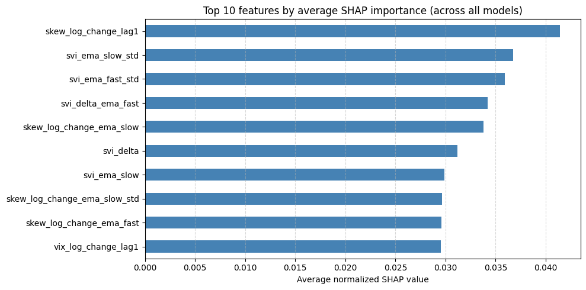

```python
top10 = mean_abs_shap_norm.head(10)

fig, ax = plt.subplots(figsize=(10, 5))
top10["avg"].sort_values().plot(kind="barh", ax=ax, color="steelblue")
ax.set_xlabel("Average normalized SHAP value")
ax.set_title("Top 10 features by average SHAP importance (across all models)")
ax.grid(axis="x", linestyle="--", alpha=0.5)
plt.tight_layout()
plt.show()
```

```python
predictions.head()
```

| date | spy_return | y_true | rw | rf252 | rf252_prob | rf504 | rf504_prob | xgb252 | xgb252_prob | xgb504 | xgb504_prob | lgb252 | lgb252_prob | lgb504 | lgb504_prob | ensemble | ensemble_prob |
| --- | --- | --- | --- | --- | --- | --- | --- | --- | --- | --- | --- | --- | --- | --- | --- | --- | --- |
| 2017-05-10 | 0.001796 | 1.0 | 0.0 | 1.0 | 0.506749 | 1.0 | 0.508959 | 0 | 0.409106 | 0 | 0.465402 | 0.0 | 0.117571 | 0.0 | 0.424201 | 0 | 0.405331 |
| 2017-05-11 | -0.002043 | 0.0 | 1.0 | 1.0 | 0.540898 | 1.0 | 0.573079 | 1 | 0.679007 | 1 | 0.590294 | 1.0 | 0.905800 | 1.0 | 0.774286 | 1 | 0.677227 |
| 2017-05-12 | -0.001671 | 0.0 | 0.0 | 1.0 | 0.526623 | 1.0 | 0.534697 | 1 | 0.523311 | 1 | 0.791502 | 1.0 | 0.923659 | 1.0 | 0.868604 | 1 | 0.694733 |
| 2017-05-15 | 0.005523 | 1.0 | 0.0 | 0.0 | 0.457485 | 1.0 | 0.500249 | 0 | 0.328764 | 0 | 0.474599 | 0.0 | 0.469020 | 1.0 | 0.770665 | 1 | 0.500130 |
| 2017-05-16 | -0.000916 | 0.0 | 1.0 | 0.0 | 0.497455 | 1.0 | 0.525468 | 1 | 0.571459 | 0 | 0.414226 | 1.0 | 0.597692 | 1.0 | 0.759749 | 1 | 0.561008 |

```python
predictions.to_csv("../Data/predictions.csv")
```

## Summary

### Feature importance

- The five most important features across all models are `skew_log_change_lag1`, `svi_ema_slow_std`, `svi_ema_fast_std`, `svi_delta_ema_fast`, and `skew_log_change_ema_slow`.
- Raw level values (e.g. how high SKEW is today) rank lower than their derived counterparts, indicating that the rate of change and its dispersion carry more predictive signal than absolute levels.